Drivers of Access to Credit in South

Africa

Submitted in fulﬁlment of the requirements for the degree Honours in

Econometrics

in the

FACULTY OF ECONOMIC AND MANAGEMENT SCIENCES

at the

UNIVERSITY OF PRETORIA

Author: Tshidiso Mofokeng, 19242175

Supervisor: Dumakude Nxumalo

Date: 24 October 2023

Drivers of Access to Credit in South

Africa

Abstract

This study extends the limited evidence on access to credit in South Africa. We investigate the

role that demographics and the transactional behaviour at individual level play in inﬂuencing the

probability of gaining access to diﬀerent types of credit. We make use of recent data from the

FinScopeSA 2019 Consumer Survey. We estimate a multinomial logit choice model to establish the

inﬂuence of various covariates on the likelihood of an individual gaining access to formal, informal,

and a combination of formal and informal credit with our reference category being those who have no

access to credit. We ﬁnd that age, income, higher educational attainment, living in Gauteng or Free

being positive and statistically signiﬁcant at increasing the probability of individuals having access

to the combination of formal and informal credit. On the other hand, Indian or Asian individuals,

employments status and remittances lowered the likelihood of an individual having access to formal

credit. Compared to being male for the combination of formal and informal credit.

1 Introduction

In the early 2000s, a small proportion of citizens in South Africa had access to credit. Most if

not all ﬁnancial institutions conducted business within their banking proﬁtability frontier and were

weary as to adopting higher risk by extending their frontier to reach the previously unbanked

individuals through various means. Bottlenecks such as ﬁnancial institutions reluctance slowed

credit extensions especially to individuals who could not provide evidence that they are low-risk

customers either via collateral or suﬃciently satisfactory earnings potential. Also, Okurut (2006)

suggested that, burning the bridge of access to credit, would be reducing asymmetric information

and market imperfections, as they tend to increase the probability of default for individuals in

the eyes of lenders. Moreover, low risk appetite from the ﬁnancial institutions has resulted in less

banks, at the time, tapping into the market of lower income individuals known as ‘risky’ customers

as they might not have seen this as a rewarding exercise.

The landscape of credit has much evolved as eﬀorts to bolster higher access to formal credit have

improved. Through policy framework such as the National Credit Act which reduced uncertainty

in the credit market, a few more banks were able to enter and extend original banks’ frontier to

reach more individuals. Moreover, the formalization of unsecured lending led to stronger bank

expansion into credit segments such as unsecured lending as well as personal loans which reached

and attracted a new and previously untouched client base. Furthermore, the likes of Capitec bank

took advantage of regulatory changes and were able to play a role in democratizing access to credit.

As a result of a few new banks entering the market, this led to expansion in the credit division

2

of banks ﬁnancial product and service oﬀerings. The spillover eﬀect has resulted in overall formal

credit signiﬁcantly improving overtime.

In South Africa, a fairly large proportion of citizens still use informal channel of credit. According

to FinMark Trust (2021), about 20% and 17% of individuals were borrowing via an informal channel

(loan shark or mashonisa) and from friends and family, respectively in the year 2022. Unequivocally,

the issue with such statistics is that this entire channel of credit still remains unregulated. Hence,

individuals have minimal protection from a legal standing. On the other hand, FinMark Trust

(2021) explains that, 88% of individuals that borrow from a formal channel of credit either borrow

from a bank or non-bank ﬁnancial institutions where the underwriter of the credit being extended

is a bank.

A few factors have been identiﬁed as drivers of access to credit on individual level. That is, personal

income as well as living in urban areas. This is owing to, income being a sound indicator to an

individuals ability to be able to repay the credit extended. Alternatively, banks may be less inclined

to extend to extend credit to those who earn grants or do not earn income at all. On the other

hand, most ﬁnancial institutions are mainly around urban areas or a metropolitan and so the greater

proximity of an individual to ﬁnancial institutions may be a driver of access to credit. Then also

age as a factor, since it may give glimpses to the borrower on the individuals how much of a credit

history a said individual has. Lastly, race may also be a factor.

In assessing what are the drivers of access to credit, more speciﬁcally, drivers of individual choices

of diﬀerent credit types. We make use of a multinomial model to predict the probability of a

given individual having access to either formal, informal or the combination of formal and informal

credit. From this we ﬁnd that, determinants with positive and statistically signiﬁcant explanatory

power in explaining why an individual would have access to formal credit are age, income, higher

educational attainment, living in Gauteng or Free State. Furthermore, for the combination of formal

and informal credit we have age, income, employment status, remittances as well as a higher living

standard measure (LSM).

Our contribution to the literature is that we seek to extend previous studies on access to credit

predominately in South Africa. From a evidence and literature perspective, much eﬀorts have

been directed towards documenting ﬁnancial inclusion. However, our focus narrows down on credit

exclusively, of which the last study which does something similar dates back to 2006. Hence, we

extend on that by using the latest data as well as information. Moreover, a feature which adds

a level of nuance from previous studies to date, which have only looked at individual channels of

access and not the combination of channels to credit. For this reason, we seek to exploit this gap in

the literature by adding another choice variable, that being, the individuals who have access to the

combination of formal and informal credit. This might not have been a possible avenue of study in

the early 2000s as regulatory ground was still young.

This study ﬁrst dives into a literature review. Then, we provide a methodology and data section.

Thereafter, we discuss the model framework in detail. Subsequently, we provide the results section

and shortly after followed by an analysis of the determinants of access to credit. In addition,

we provide a discussion section and before concluding we mention a few limitations and areas for

further research.

3

[figure not shown]

2 Literature review

Financial inclusion is deﬁned as individual access to a diverse range of products. These include

being a transactional account, payments, savings, credit and insurance (World Bank, n.d.). The

Financial Sector Regulation Act of South Africa similarly deﬁnes it with individuals having access

to appropriate and aﬀordable ﬁnancial products and services (Financial Sector Conduct Authority

2020). Financial inclusion can also be, according to National Treasury (2020), the provision and

utilization of inexpensive and acceptable ﬁnancial services by those parts of society where ﬁnancial

services are required but are not available or are given in an unsatisfactory manner. By deﬁnition

alone, we note that ﬁnancial inclusion is broad as it refers to various types of products. Conse-

quently, eﬀorts at improving it may not be as focused and in essence challenging to achieve, given

the level of broadness. An individual having an account and being able to facilitate transactions

through basic banking services quantiﬁes them as being ﬁnancially included. However, for the

purpose of this paper we will be diving deeper into one of the branches of ﬁnancial inclusion, that

being credit. Access to credit is not as broad as ﬁnancial inclusion. An individual can be ﬁnancially

included; however, they might not have access to credit. Furthermore, Robert Cull and Jonathan

Morduch (2017) explains that, lack of access to credit or any other formal ﬁnancial service does

not imply that the same group of individuals (given they are poor or unemployed) will not have

access to any ﬁnancial services.

Credit quality of an individual plays an important role, especially with huge acquisitions such as

homes. Barakova et al. (2003) ﬁnds that, strong credit scores seems to improve the likelihood of

owning assets such as vehicles and houses. However, the only way to have a strong credit score

is to have access to credit, this in turn improves your credit quality. Moreover, the role access to

credit plays is signiﬁcant, in that, individuals are allowed to accumulate ‘wealth’ through, investing

in human capital from household level, which comes down to improving future or potential output

(National Treasury 2011). Kumar et al. (2020) explains how access to credit sources for rural

households can enhance household income and reduce poverty.

Fatoki, Van, and Smit (2011) suggests that, credit rationing factors such as asymmetric information,

moral hazard as well as adverse selection weigh in on the limitations for micro businesses on being

granted access to credit, implicitly boiling down to the capital structure of such businesses. More

so, the assets in ownership that can be used as collateral. These micro businesses such as street

vendors or corner stores, are largely an extension of an individual. This implies that any credit that

is extended to these micro businesses are predominately applied for through personal ﬁnancing, in

essence, the owner has unlimited liability or is fully liable for the repayment of the debt in the case

that the business is no longer able to generate revenue (Masiak et al. 2019). Given the signiﬁcant

role micro businesses play in the informal sector of the economy with employment 1for semi- and

unskilled-labour especially in developing nations, we may appreciate how access to credit adds a

layer of economic transformation which can be more meaningful than ﬁnancial inclusion which is

diversiﬁed over not only credit but other products as well (National Treasury 2020).

Historically, South Africa has had low levels of access to credit. Okurut (2006) explains how

salaried workers in the period of 1995, who were predominately white, are more likely to gain

access to credit. This indirectly implied that citizens who did not have a payslip or anything to use

as collateral (house, car, investments) were most likely excluded from the credit market. In 1995,

approximately 10.49% of citizens only had access to credit. At national level considering all races

1The informal sector contributes an estimated 36% to GDP and contribution and it also contributes about 47%

towards employment, according to (StatsSA 2019).

4

and genders, saw an increase in access to credit to 23.45% by the year 2000. According to FinMark

Trust (2009), some banks felt less inclined to extend their banking frontier to reach lower income

individuals’ or the unbanked market.

FinMark Trust (2009) further explains that, ﬁnancial products such as the Mzansi bank account

helped to encourage banks to consider banking those at the near bottom of the income pyramid

through reaching the so called last frontier of proﬁtability. On the other hand, there are a few

fast growing ﬁrms i.e. Discovery Bank, Bank Zero and TymeDigital aiming to claim a market

share of the banking sector, through various ﬁnancial product and service oﬀerings including credit

extensions.

A few supply-side factors cause barriers to entry to credit markets. Given that legal framework

was a huge gap in the credit market around early 2000s, the National Credit Regulation which was

formed by the National Credit Act (NCA) closed this gap after being established in 2005. The

NCA which then oversaw regulation in the credit industry in South Africa, helped improve overall

access to credit since its inception around mid 2006 (Kelly-Louw 2006). This policy move assisted

Capitec in taking full advantage by oﬀering higher loan amounts and longer repayment terms

(Trudi Makhaya and Nicholas Nhundu 2016). This led to Capitec capturing a higher proportion

of the middle and even lower income class. The NCA doing away with capital restraints under the

Usury Act, saw Capitec expanding quicker via their credit segment which spilled over into a larger

transactional customer base (Trudi Makhaya and Nicholas Nhundu 2016). More speciﬁcally, this

bolstered growth in the overall credit market.

store cards and store accounts since the underwriter of this credit facility is a commercial bank, as

at 2021 (FinMark Trust 2021). Overall, holding all other factors constant, we have seen a signiﬁcant

increase in access to credit (all types of credit) from early 2000s to 2021. However, a number of

individuals still use the informal channel of credit as, of which the usage has largely been driven by

short term consumption uses instead of longer term productive uses. According to FinMark Trust

(2021), about 37% of individuals still make use of informal credit channel of which includes loan

sharks as well as borrowing from friends and family, which is a substantial amount of individuals.

Household or individual characteristics are also drivers of credit access in South Africa. The only

South African study that evaluates access to credit was done in 2006 by Okurut. Okurut (2006)

examines and ﬁnds that, determinants of access to credit would be employment status, education

level, age, per capita expenditure, race and whether an individual is male. This is for the formal

sector. Moreover, there is an added negative contribution towards predicting the dependent variable

in the model that being whether an individual is poor or not. This eﬀect can be controlled for with

income where an individual who earns below a set threshold could be considered poor or perhaps

those who fail to meet collateral requirement thresholds are factors that also play a signiﬁcant

role. Okurut (2006) then extends his analysis for the semi-formal sector, by mentioning that an

individual being unemployed is not a signiﬁcant reason as to why the barriers to entry might be

high for the given individual. He notes that household size, per capita expenditure, provincial

location, gender, being poor, staying in rural areas and race played a signiﬁcant role in determining

whether an individual would have access to semi-formal credit. Then, for the informal sector, are

simply provincial location, education level and race. From the onset we see how the formal sector

takes up much more variables which focus on whether a said individual can qualify and aﬀord

access to credit using a multinomial logit model. The number of drivers in the semi-formal and

informal sector are more relaxed for the former and extremely relaxed for the latter. The semi-

formal and informal sector do not necessarily run a form of regression model to determine whether

5

an individual has access merely due to the nature of the client base being unemployed in most cases

and even poor. The take on risk from borrowers is much higher given that such a client base is

more susceptible to default, as a result, the interest on such forms of credit tend to be way higher

than formal traditional commercial banks. Lastly, Okurut (2006) focused on variables that were

consistent in both sample periods of 1995 and 2000 as well as coeﬃcients with consistent signs.

This study was however conducted in 2006. There has been notable developments in access as

well as demographics that may have been important in back then but may no longer capture. For

instance, the expansion of banks in more locations may result in the geographic variable no longer

holding explanatory power.

In other studies from Vietnam, household and individual characteristics have also been identiﬁed as

important in explaining access to credit. Quach, Mullineux, and Murinde (2005) suggested a similar

approach in line with with quantifying the impact of access to credit on economic welfare of house-

holds to Okurut at household level. Characteristics that play a role in whether a household receives

access to credit are; age of household head, gender of household head, size of household, education,

ownership of land, household per capita food spending and non-food spending, household assets.

Quach, Mullineux, and Murinde (2005) focused on agricultural data, and found that land owner-

ship was most important in whether a farmer gained access to credit or not, with this explanatory

variable being signiﬁcant at a 1% level. At the time borrowers required land ownership certiﬁcation

in the administration process prior to approving credit extensions. Here characteristics inﬂuencing

whether a rural households ability to borrow includes; age of household head, education, household

size, land size and ownership of land, livestock or assets, direct cash transfer (grants), remittances

and source of income. The only sources of borrowing are via formal (commercial banks, micro-

ﬁnance institutions, cooperative bank) and informal (relatives or friends, money lender). Lastly,

Linh et al. (2019) looks at determinants of access to capital and mentions them namely as; gender,

age, household size, distance between borrower and lender, education, access to information, area of

land, assets (which can be used as collateral), household savings, marital status, past credit, social

capital - how many people one could ask for help or just reputation. Among the most important,

age, education, assets, credit record and income.

3 Methodology and Data

A data source which provides us with relevant data for our research, will be obtained from FinMark

Trust, FinScope survey of 2019. The FinScope survey is conducted each year in order to track

and better understand individual and households access to, use of as well as demand for ﬁnancial

products and services. Through interviewing respondents’, the level of participation in the ﬁnancial

services through savings, credit usage, and other ﬁnancial products was captured. The 2019 survey

is comprised of a sample of 4969 individuals. Additionally, all races were accounted for, a nationally

representative sample of 16 years + participants were captured in the survey which was weighted

and bench-marked according to the mid-year population estimates (StatsSA 2019). Here we have,

nationally representative survey and weighted these individuals represent 40.9 million citizens - see

table 1. The sample design was outsourced by a third party. A tablet was used to collect the data

through face to face interviews, with the questionnaire having the option of being translated into

isiXhosa, isiZulu, Sesotho, Setswana, Sepedi and Afrikaans. This gives us added layers of assurance

with respect to the quality and reliability of the survey data.

The goal was for us to categorize individuals into four diﬀerent groups. Namely those with access

to, formal credit, informal credit, formal and informal credit and no credit which forms our choice

6

variables. Firstly, we deﬁned individuals with access to formal credit as those who in the past 12

months have successfully been able to borrow capital either from a bank, Retail Store (e.g. Wool-

worths, Edgars etc), Insurance company, Micro ﬁnance institution e.g. Wonga, Village bank or

Co-operative bank (e.g. Yebo, Iemas), Development bank, NGO or government. Secondly, we then

classiﬁed informal credit category as those who in the past 12 months have successfully been able to

borrow capital either from an employer (including getting an advance on your salary), mashonisa

or loan shark, stokvel society, burial society, umgalelo or savings club, Pawn shop, borrowed or

taken goods (e.g. sugar, bread, milk, candles etc) or paying overtime for things on the book from

a local spaza, general dealer, corner cafe or shop, colleagues or neighbours, friends or family or

household member. Lastly, anyone who in the past 12 months did not borrow through either a

formal or informal credit avenue was classiﬁed as not having access to credit.

There are subtle diﬀerences on the approach we take compared to the likes of (Okurut 2006). That

is, Okurut (2006) deﬁned three types of credit: formal, semi-formal and informal. By his deﬁni-

tion, formal included credit strictly from commercial banks. Semi-formal included store accounts

and store cards which are predominately associated with concept of consumption credit. Then,

informal credit would include borrowing from friends and family. In our paper, we opted to draw

a line between formal and informal; where, if the borrower is the bank or the credit is being un-

derwritten by a ﬁnancial institution through a retailer that oﬀers a store card to an individual.

Then we classify that as formal credit. Conversely, any borrowing that is not underwritten by a

ﬁnancial institution, then we classify that as informal credit. Furthermore, we consider evaluating

individuals who use the combination of formal and informal credit. A choice not considered by

Okurut (2006). Due to, institutional factors, Okurut (2006) explains that, banks limited credit

supply by placing barriers since the opportunity cost of assessing whether an individual without

minimum requirements qualiﬁes was not a rewarding exercise. However, lowered barriers as well as

a increased frontier has encouraged more banks overlook fact that in some if not most cases, it is

not a rewarding case.

From table 1, we notice the channel with the highest individuals is formal credit followed by informal

credit with 458 and 369 individuals respectively. We noted that there were about 111 observations

which had a combination of both formal and informal credit. The individuals or households that

had access to both formal and informal credit according to the weighting of the 2019 StatsSA

estimates were about 608,813 - see table 1. The environment and market for credit usage has

evolved signiﬁcantly from the early 2000s where one would most likely only have access to one

form of credit channel. For instance, those who already had access to formal credit might have seen

informal credit being too expensive with respect to the debt servicing cost. On the other hand, those

with access to informal credit might not have been able to access formal channels given the high

barriers of entry. However, the landscape is much more diﬀerent; whereby, individuals do indeed

participate through combinations of both formal and informal channels. Much so that, removing

this from the data set would merely be as interesting as adding this level for study purposes. We

keep this as a choice in order to incorporate these borrowing dynamics.

7

[figure not shown]

Table 1: Summary by Credit Type

Credit type Count Weighting to Population

Formal credit 458 3 037 996

Informal credit 369 3 460 289

Formal and Informal credit 111 608 813

No credit 4 026 33 799 637

Total 4 964 40 906 735

We then noted 5 individuals in the data, otherwise relatively speaking about 36,699 citizens ac-

cording to the weighting scale, who did not record that they have access to either formal, informal,

formal and informal as well as no credit. This is approximately 0.1% of our sample which will be

excluded. Hence, the sample was reduced to a total of 4964. Thus, based on the above deﬁned

types of credit we categorized individuals into their relevant grouping by credit type - see table 1.

4 Descriptive Statistics

Table 2 provides the population weighted averages for individuals of the individual characteristics

used in our analysis by credit type. The characteristics of interest would include the demographics

of the individuals such as household size, age, income, race, income, provincial location, employment

status, marriage status, educational level and LSM. In addition, transaction behaviour based on

whether an individual is cash based or not which includes remittances as well as if an individual is

cash based on household spending.

Firstly, for demographics, we that individuals who have access to formal credit, earn R14,382 on

average compared to individuals with access to informal credit who earn around R5032 on average.

As expected individuals who use a combination of formal and informal credit, on average, earn

almost 3x more than just those who use informal credit. In building the data set, those who belong

to or participate in savings groups, stokvel groups, burial groups, or any other groups were all

deﬁned as individuals belonging to a social group. From this, we noted that such individuals were

participating, on average, 58% via the combination channel of formal and informal credit but even

higher for informal credit which was 61%. Intuitively, most ﬁnancial institutions have only in recent

years started creating ﬁnancial products such as stokvel accounts, in eﬀorts to start banking much

of the previously unbanked communities. Table 2 also indicates how the Black individuals have

higher access to informal and no access to credit at 89% and 79% respectively. Moreover, White

individuals have a greater proportion of individuals with access to formal credit, compared to,

informal as well as no credit where those percentages are relatively low. On the contrary, Indian or

Asian individuals have the lowest access to all channels of credit. We expect individuals from rural

areas to have low participation rates for ﬁnancial inclusion and subsequently access to diﬀerent types

of credit compared to individuals in urban areas, that is 13% in rural areas which is 4.9x lower than

those who use formal credit in urban areas. On the other hand, in line with expectation, evidence

conﬁrms that 93% of individuals who are employed have access to the combination of formal and

informal credit in comparison to unemployed individuals who approximately do not have access to

formal credit. Higher percentage of unemployed individuals are prone to either having access to

informal credit and even no access at all to credit. This could be explained by the employment

ﬁgures of the nation, with less individuals having quality (high-skilled) jobs in the composition of

8

the labour market. Also, one may overlay the high income inequality disparity in South Africa,

which may lead to banks being cautious as to the kind of clients that credit is being extended to.

Lastly, with respect to remittances, we expect formal institutions to be more reluctant to extend

credit to individuals who send money out of the country. Formal lending institutions in most cases

may have such information on their clientele, however, this would not entirely invoke a blockage

on the supply of credit.

9

[figure not shown]

Table 2: Descriptive statistics

Credit type Formal and Informal credit Formal credit Informal credit No credit Description

Household size 3.37 3.45 4.23 3.88 Average number of people living in a household

Age 37.88 39.94 40.31 38.12 Average age of respondents

Male 0.44 0.56 0.42 0.48 1 if are male

Personal Income 13828.48 14381.87 5031.63 4961.93 Average total monthly personal income before

deductions

Household income 5.40 5.53 4.43 4.44 Average household income by ranges with 5 being

those between R8000 - R11,999

Grant 0.14 0.13 0.37 0.29 1 if you do receive a grant

Social group 0.58 0.37 0.61 0.35 1 if you do belong to social group

Black 0.73 0.68 0.89 0.79 1 if you are Black

Coloured 0.05 0.07 0.08 0.09 1 if you are Coloured

Indian Asian 0.05 0.04 0.01 0.03 1 if you are Indian or Asian

White 0.16 0.21 0.02 0.09 1 if you are White

Eastern Cape 0.13 0.07 0.09 0.11 1 if you are from Eastern Cape

Free State 0.03 0.05 0.02 0.05 1 if you are from Free State

Gauteng 0.35 0.45 0.27 0.26 1 if you are from Gauteng

KwaZulu Natal 0.25 0.19 0.21 0.18 1 if you are from KwaZulu Natal

Limpopo 0.06 0.05 0.15 0.09 1 if you are from Limpopo

Mpumalanga 0.02 0.08 0.08 0.08 1 if you are from Mpumalanga

North West 0.01 0.01 0.02 0.02 1 if you are from North West

Northern Cape 0.01 0.01 0.02 0.02 1 if you are from Northern Cape

Western Cape 0.10 0.06 0.11 0.13 1 if you are from Western Cape

Metro urban 0.62 0.57 0.43 0.40 1 if you are from metro urban

Non-metro urban 0.29 0.30 0.26 0.33 1 if you are from non-metro urban

Rural 0.09 0.13 0.31 0.27 1 if you are from a rural area

Married 0.43 0.43 0.22 0.25 1 if you are married

Co-habitating 0.19 0.07 0.14 0.09 1 if you are co-habitating

Employed 0.93 0.83 0.57 0.44 1 if you are employed

Unemployed strict 0.07 0.11 0.29 0.31 1 if you are unemplyed by strict deﬁnition

Unemployed narrow 0.02 0.09 0.27 0.28 1 if you are unemplyed by narrow deﬁnition

No education 0.00 0.01 0.01 0.00 1 if have no education

Primary education 0.00 0.02 0.06 0.04 1 if have primary education

Secondary education 0.67 0.56 0.80 0.83 1 if have secondary education

Tertiary education 0.33 0.40 0.13 0.12 1 if you have tertiary educatopm

Remittances 0.54 0.35 0.34 0.15 1 if you have sent remittances

Remittances within SA 0.53 0.34 0.33 0.14 1 if you have sent remittances within South Africa

Remittances outside SA 0.08 0.03 0.01 0.01 1 if you have sent remittances outside South

Africa

Cash 0.91 0.75 0.94 0.88 1 if you buy food/groceries using cash

Wallet money 0.01 0.01 0.01 0.00 1 if you buy food/groceries using E-wallet or

instant money

10

[figure not shown]

5 Model framework

We make use of the multinomial logit model in order to determine the eﬀect of various characteristics

on the likelihood of gaining access to the diﬀerent categories of credit. In essence, our goal is to

try and understand why an individual will receive either formal, informal, formal and informal

or no access to credit. That gives us four response variables, with our reference group being the

participants’ of the survey that do not have access to credit. Our reference group implies that, all

coeﬃcients associated with no credit have been normalized to zero, meaning that our results are

interpreted with respect to individuals having no credit. Given a variety of covariates, we seek to

explain what the probability is of having access to a certain type of credit.

An alternative discrete choice probability model we could have considered would revolve around

the Linear Probability Model (LPM) which simply is strictly a binary response model that takes

on a qualitative dependent variable (Wooldridge 2012). The interpretation thereafter would be in

terms of the probability or rather changes in probability. However, the outcome as would be binary

given the nature of the model only being a binary response model. This model would inherently

pose a challenge to the work we are trying to unmask here, owing to the fact that, we are interested

in an outcome that takes on four responses. Moreover, probabilities are deﬁned between zero and

one; however, for the LPM some extreme probabilities (outliers) may fall outside these bounds.

Consequently, this runs us into statistical problems. Another shortcoming is that the marginal

eﬀects, for interpretation purposes, for any explanatory variable that appears in level form will be

constant. Hence, we can not use the LPM estimation approach. We then turn to the multinomial

logit model of estimation. This overcomes the shortcomings of the LPM mentioned above, although

the interpretation does become a bit more challenging as we move outside of the world of Ordinary

Least Squares. A richer model would not only look at formal vs informal credit. We now need to

turn to a increasingly ﬂexible model which will help us answer our question.

y=

1,if formal credit

2,if informal credit

3,if formal and informal credit

4,if no credit

Hence, we have our probability function given as:

E(y|Xi) = P(y=i|xi) = G(αi0+γi1xn1+γi2xn2+... +γikxnk) = G(xnkγik)

for i = 1, 2, 3 and 4 and also where 0 ≤G(.) ≤1. The multinomial logit closed form expressions

uses an extreme value distribution for G (Train 2009). Hence, this produces the following choice

probability,

Pni =evni

P4

j=1 evnj

where vni =xnkγik and where n represents person n in our sample.

The discrete choice (in our case the multinomial model) analysis will focus on deﬁning the model

as we have above and then interpreting the estimates which will follow in the results section. We

assume strict exogeniety for our unobservable factors or error term with our explanatory variables.

11

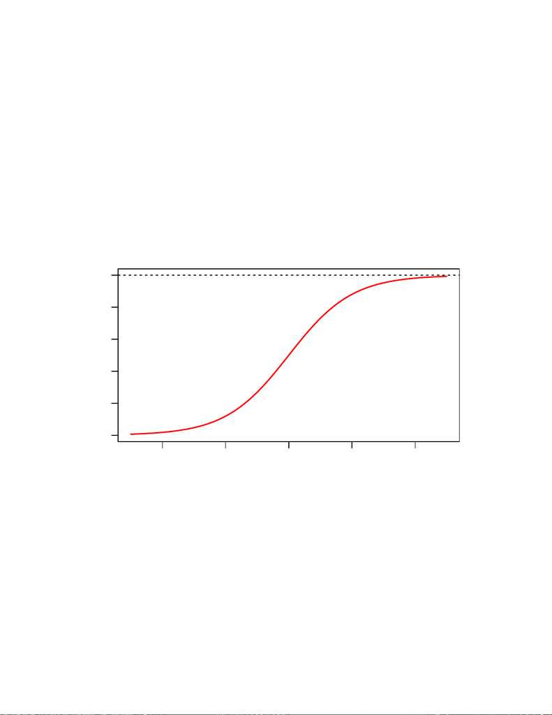

Other properties for the choice probability include that our probabilities are indeed bounded be-

tween zero and one - a prerequisite for a probability by deﬁnition - as shown in ﬁgure 1. Given

that eis a strictly increasing function the probability approaches one as vni increases, the converse

also holds. Additionally, the denominator (in the above deﬁned logit choice probability) ensures

that the choice probabilities add up to one. This makes it slightly easier to interpret the probabil-

ities, given that the denominator is just the sum of all the alternatives. The alternatives being the

diﬀerent types of access to credit. Hence, an increase in the usage of formal credit may reduce the

probability of usage of informal credit. The characteristics that feed into predicting the probability

of the diﬀerent types of credit is household size, age, gender, personal income, household expendi-

ture, ethnic group, province of residence, whether one stays in an urban metro or non-metro that

is urban, marriage status, employment status, education level, levels of remittances, whether an

individual is cash based as well as other variables.

−4 −2 0 2 4

0.0 0.2 0.4 0.6 0.8 1.0

Figure 1: Logit curve

Vni

Probability

Consider we are interested in understanding the marginal eﬀect of education, more speciﬁcally

tertiary education on the probability of an individual having access to formal credit. As mentioned

earlier, running a regression of formal credit on education as well as other explanatory variables

and reading the coeﬃcient on education will only yield an incorrect interpretation of the magnitude

of education even though the sign of the coeﬃcient may be correct. For this reason, we seek to

take a further step in reaching an interpretable solution to the problem. Given that that tertiary

education is a binary variable, for instance, an individual can either have tertiary education or

not. Hence, we take our marginal eﬀect on tertiary education accounting for the discrete nature

of the function with respect to how the function will be diﬀerentiated, using the chain rule from

calculus. According to (Cameron and Trivedi 2005), the marginal eﬀect averaged over individuals

will become,

12

[figure not shown]

∂Pni

∂xnk

=N−1

N

X

i=1

Pni (γik −¯γnk)

where, N= 4964 and

¯γnk =X

∀l

Pnl γlk

In our case, γik is the estimate on tertiary education for a certain type of credit(y = 1, 2, 3 and 4).

Having Pnl be the predicted probabilities of an individual choosing the diﬀerent types credit then

¯γnk becomes the probability weighted average of the estimate on tertiary education (γik). Thus,

to obtain the marginal eﬀect we would just multiply the predicted probability by the diﬀerence

between the estimate and the weighted average of the estimate. This yields that the true eﬀect of

an additional year of tertiary education, results in an increase in the probability of an individual

or household gaining access to formal credit, holding all other variables constant. Since we want

the marginal eﬀect averaged over all individuals in our sample, we multiply by N−1.

6 Results

In this section, the estimates are presented. From this we seek to analyse the results in order to

further understand what factors drove the probability of an individual receiving access to either of

the respective channels of credit. Table 3 presents the marginal eﬀects estimates or factors aﬀecting

individuals and households access to formal, informal as well as formal and informal credit. Having

explained our reference option, we would like to know why there are marginal estimates for that

option.

Table 3: Regression Estimates for Multinomial Regression

Formal credit Formal and Informal credit Informal credit

Household size 0.000 0.000 0.000 ***

(0.033) (0.072) (0.027)

Age 0.005 *** 0.002 ** 0.008 ***

(0.031) (0.081) (0.027)

Age squared 0.000 *** -0.000** 0.000 ***

(0.000) (0.001) (0.000)

Male 0.015 -0.005* 0.005

(0.115) (0.234) (0.127)

Log of personal income 0.035 *** 0.003 * 0.004 **

(0.084) (0.172) (0.054)

Black -0.040 -0.001 0.096 ***

(0.166) (0.356) (0.320)

Coloured -0.018 -0.006 0.090 ***

(0.200) (0.462) (0.333)

Indian Asian -0.047** 0.000 0.055

(0.259) (0.488) (0.440)

Eastern Cape -0.009 0.009 -0.022

(0.352) (0.761) (0.312)

Free State 0.046 ** 0.002 -0.052

(0.342) (0.854) (0.364)

Gauteng 0.035 * -0.002 -0.019

(0.326) (0.762) (0.308)

KwaZulu Natal 0.013 0.006 -0.018

(0.326) (0.751) (0.297)

Limpopo -0.006 0.005 0.006

13

[figure not shown]

Table 3: Regression Estimates for Multinomial Regression (continued)

Formal credit Formal and Informal credit Informal credit

(0.386) (0.836) (0.308)

Mpumalanga 0.051 -0.012 0.002

(0.350) (1.021) (0.327)

North West 0.011 0.007 -0.034

(0.370) (0.818) (0.330)

Western Cape -0.035 0.003 0.013

(0.361) (0.790) (0.309)

Married 0.007 0.005 -0.030**

(0.126) (0.253) (0.139)

Employed -0.014* 0.015 *** -0.027

(0.190) (0.517) (0.164)

Tertiary education 0.020 *** -0.004 0.007

(0.137) (0.278) (0.175)

Grant 0.002 0.004 0.022 **

(0.199) (0.388) (0.151)

Metro urban 0.006 0.002 0.023 **

(0.146) (0.290) (0.157)

Remittances -0.009*** 0.011 *** 0.011 ***

(0.126) (0.233) (0.131)

LSM 0.001 0.004 *** -0.005

(0.048) (0.100) (0.049)

Note:

Observations: 4,964

Percentage correctly predicted: 85.75

Log Likelihood: -2.667.386

Likelihood Ratio Test: 1,296.429*** (df = 72)

Pseudo R-squared: .196

*Signiﬁcance levels: ‘***’ 0.01 ‘**’ 0.05 ‘*’ 0.1

7 Determinants of Access to Credit

We ﬁnd that, household size is only signiﬁcant for the informal credit market with no signiﬁcance

for the other channels of credit. Nonetheless, the marginal eﬀects across all channels of credit are

negligible. Our age variable provides us with statistically signiﬁcant results across all channels of

credit. This is consistent with expectation, in that, the older an individual becomes, the more

likely they will be able one is to take on credit either for short term consumption or long term

productive reasons. We also have evidence of nonlinearity, that is nonlinear marginal eﬀects of

age squared which also proves to be consistent with expectation. However, employment surprising

seems to negatively and statistically signiﬁcantly at a 10% level to reduce an individual’s probability

of having access to formal credit. Although, it is positive and signiﬁcant at a 1% level for the

combination of formal and informal credit. Employment and educational attainment may not be

as important for access to informal credit. Table 3 validates this as shown by the respective levels

of signiﬁcance. Being married and being male is only signiﬁcant for informal as well as for formal

and informal access to credit respectively.

Higher income is associated with a better likelihood of access to formal credit. Since we have this

as a semi-elasticity, we ﬁnd that, if an individual’s income increases by 10% this translates to a

by 0.35 percentage point rise the probability of access to formal credit, once other factors have

been controlled for. The marginal eﬀect for the log of personal income is 8.75x higher for access

to formal credit compared to access for informal credit, which is a substantially large diﬀerence.

This also indicates how much of importance, personal income is in improving an individuals access

14

to a formal channel of credit. Income is signiﬁcant across all type of credit in the results. Grant

individuals, who have receive this as a source of income, are more likely to have access to informal

credit at a 5% level of signiﬁcance.

In table 2, we found Black individuals having a greater proportion of access to informal credit.

This also held up for the Coloured individuals, who for this group, access to informal credit was the

second highest after no access to credit. In our results, we note Black and Coloured individuals both

with a positive and statistically signiﬁcant at a 1% level probability of having access to informal

credit, than White individuals our base group. On the contrary, Indian or Asian individuals indicate

a negative and statistically signiﬁcant probability of having access to formal credit, than White

individuals our base group. This is interesting, since access to formal credit was the second largest

proportion, with respect to the other credit types in table 2.

Moreover, a higher educational attainment seems to improve your probability of gaining access to

formal credit. That is, at a 1% level of signiﬁcance, tertiary education improves your probability

by 0.02, after controlling for other factors. Furthermore, geographically speaking, Free State as

well as Gauteng are statistically more likely to have access to formal credit. Interestingly, residing

factors constant.

Hereafter, we ﬁnd that individuals that partake in remittances being inside or outside South Africa

are statistically less likely to gain access to formal, but more likely for informal and the combination

of formal and informal credit. We expect formal lending institutions to be more cautious about

lending to customers that send money out of the country. Lastly, we note that a higher LSM (living

standard measure) corresponds to gaining access to the combination of formal and informal, as this

is statistically signiﬁcant only for this channel of credit.

Overall, the goodness of ﬁt measures are sound. Given our various credit type outcomes, the

number for which our model correctly predicted the type of credit that they used. We ﬁnd that,

85.75% of our sample held up and was accounted for by the model. The pseudo r-squared, which

is equivalent to the r-squared for OLS and based on log-likelihoods, is 19.6% for the model. The

likelihood ratio test is signiﬁcant at a 1% level.

8 Discussion

Given the estimates from the results section we found various household characteristics and ex-

planatory variables statistically signiﬁcant either across all credit channels or for selected credit

channels. An addition from an evidence point of view is how we try to understand the impact of

respective explanatory variables on the combination of formal and informal credit. The signiﬁcance

held up in line with most estimates. However, LSM was the only statistically signiﬁcant variable

for this channel of credit with respect to the other channels. Higher LSM does not explain whether

an individual or household will gain access to either informal or formal credit; despite that, it is

an almost negligible marginal eﬀect, it does explain that higher LSM increased the likelihood of

obtaining access to formal and informal credit. This is similar for our coeﬃcient on being male.

In line with prior research, we can make inference that perhaps certain factors do not play as a

highlighted role in the earlier 2000s in terms of obtaining access to credit. Such as for geography,

the distance from ﬁnancial institutions does not play as a bigger role. Even though the FSC has

15

timeously communicated that more bank branches be built in rural areas, digitization seems to be

leapfrogging the phase of physical infrastructure. As a result of ﬁnancial institutions going digital,

online banking has simpliﬁed what initially were administratively challenging problems. Eﬀectively,

making it more easier to obtain credit. From a regulatory perspective, the Usury Act protected

ﬁnancial institutions from partaking unsecured lending segments and from extending credit for

lower loan amounts and higher interest rates, eﬀectively governing credit extension transactions

and protecting customers from risks of defaulting (Mohane, Coetzee, and Grant 2000). The FSC as

well as the NCA, were front runners of driving economic transformation from a ﬁnancial inclusion

and access to credit point of view respectively. For instance, the NCA allowed for more certainty

within the unsecured lending market which saw restriction outlaid by the Usury Act fall away,

eﬀectively allowing for growth for the likes Capitec as well as the dominant big four Banks (Trudi

Makhaya and Nicholas Nhundu 2016). This in turn made it easier for previously unbanked and

middle to lower class individuals also participate in the ﬁnancial sector. Moreover, gain access to

various credit segments. Despite that, there has been satisfying progress with regard to access to

credit, especially with the advancement of technology and more digitization of ﬁnancial institutions

product and service oﬀering.

It is interesting that being married only signiﬁcantly explains why individuals have access to in-

formal credit and not the other channels. Expectation was that there be signiﬁcance across all

channels of credit, since more married households might consider taking up formal credit via mort-

gage loans and perhaps vehicle ﬁnancing. Also, given that a married couple might present a higher

potential household income; although, it would be cumbersome not to consider that household

expenditure might also increase. That is, a married couple might have a dual income household

but having children might add constraints on the household budget with new expenses to consider

such as tuition, medical costs, extra-curricular activities and other factors for consideration.

9 Limitations and areas for further research

The limitation of our selected estimation model, the multinomial logit model, is that we do not have

supply-side constraints. One of which is the quality of services oﬀered by borrowers of capital. A

consequence of this is that there could be a disconnect with customers expectations with respect to

being to make an adequate comparison across borrowers. This might make it more challenging to

asses which bank in the formal credit market can address your concern. Hence, having information

on the quality service might create transparency in the credit and open room for an enhanced

experience. The last and most important constraint is prices. Banks use diﬀerent models to assess

an individuals likelihood of defaulting. As a result, understanding what feeds into the pricing of

diﬀerent banks may assist individuals in making well informed decisions. As it stands, customer

only use their credit score as a measure or bargaining tool when it comes to negotiating a lower

price (interest rate) for capital. However, this may look diﬀerent for customer A and customer

B as inherently their characteristic and credit history will diﬀer. The extent as to how these

constraints eﬀects the levels of accessibility that individuals in South Africa is unknown and could

oﬀer individuals with better information prior to making contractually binding decisions. Another

limitation of our study is that we do not consider the eﬀects or harms that could emanate from credit

access. We note that a positive eﬀect has been improved welfare. However, there negative eﬀect

of access to credit could come in the form of risks of over indebtedness. For instance, unsecured

lending channel’s spending trends indicates 47% of credit active consumers being three of more

months in arrears, while averaging a salary or wage of less than R7500.

16

10 Conclusion

In this paper, we extended the literature on the determinants of access to credit in South Africa

at individual level. We studied the diﬀerent credit types or categories that an individual might be

classiﬁed under given various respective household characteristics as well as other covariates that

explain this. We then further included an added level of nuance by incorporating the combination

of formal and informal credit, which was not a choice variable in previous literature owing to the

banking sector as well as the regulation of credit being relatively new at the time.

Our evidence of how the landscape of credit in South Africa has evolved since the early 2000s.

determining whether an individual gains access to diﬀerent types of credit. From an administrative

view, the advancement of South Africa’s digit banking technology has led to more individuals easily

being able to obtain credit. Hence, the more important covariates that explain an individuals

probability to gain access to credit is age, income, educational attainment, employment status as

well as levels of remittances.

Building wealth as individual in most cases is better ﬁnanced through a formal institution. Indi-

viduals who struggle to provide future earnings potential, higher educational attainment levels and

younger in age may face barriers in acquiring access to formal credit. This comes as a consequence

of ﬁnancial institutions assessing a high risk proﬁle for the individual; subsequently, a high default

rate. High levels of indebtedness in South Africa and even the high debt to disposable income

overlays an argument that individual preferences for credit are leaning more toward short term

consumption purposes. Owing to this limitation, we did not evaluate the overall welfare eﬀects of

credit usage and if it is being used wisely or recklessly. Our study, extended the literature on access

to credit and what factors inﬂuence this at individual level, for which we conclude there has been

signiﬁcant growth.

17

Bibilography

Barakova, Irina, Raphael W. Bostic, Paul S. Calem, and Susan M. Wachter. 2003. “Does Credit

Quality Matter for Homeownership?” Journal of Housing Economics 12: 318–36. https://doi.

org/10.1016/j.jhe.2003.09.002.

Cameron, A Colin, and Pravin K Trivedi. 2005. Microeconometrics: Methods and Applications.

Cambridge university press.

Fatoki, Olawale Olufunso, A Van, and Aardt Smit. 2011. “Constraints to Credit Access by New

SMEs in South Africa: A Supply-Side Analysis.” African Journal of Business Management 5:

1413–25. https://doi.org/10.5897/AJBM10.1335.

Financial Sector Conduct Authority. 2020. “FINANCIAL INCLUSION STRATEGY.” https://

www.fsca.co.za/Documents/FSCA%20Financial%20Inclusion%20Strategy.pdf.

FinMark Trust. 2009. “Msanzi Bank Account Initiative South Africa.” 2009. https://ﬁnmark.

org.za/system/documents/ﬁles/000/000/316/original/MsanziBankAccInitiativeSA_2009.pdf?

1614593520.

———. 2021. “FinScope SA Consumer Survey.” 2021. https://www.fsca.co.za/Documents/

FinScope%20SA%20Consumer%202021%20Survey%20%20Results%20Prepared%20for%

20FSCA.pdf.

Kelly-Louw, M. 2006. “THE NATIONAL CREDIT ACT AND ITS REGULATIONS IN THE

CONTEXT OF ACCESS TO FINANCE IN SOUTH AFRICA RP Goodwin-Groen with Input

From.”

Kumar, Anjani, Ashok K. Mishra, Vinay K. Sonkar, and Sunil Saroj. 2020. “Access to Credit

and Economic Well-Being of Rural Households: Evidence from Eastern India.” Journal of

Agricultural and Resource Economics 45: 145–60. https://doi.org/10.22004/ag.econ.298439.

Linh, Ta Nhat, Hoang Thanh Long, Le Van Chi, Le Thanh Tam, and Philippe Lebailly. 2019.

“Access to Rural Credit Markets in Developing Countries, the Case of Vietnam: A Literature

Review.” Sustainability (Switzerland). MDPI. https://doi.org/10.3390/su11051468.

Masiak, Christian, Joern H Block, Alexandra Moritz, Frank Lang, and Helmut Kraemer-Eis. 2019.

“How Do Micro Firms Diﬀer in Their Financing Patterns from Larger SMEs?” Venture Capital

21 (4): 301–25.

Mohane, Happy, Gerhard K Coetzee, and William Grant. 2000. “The Eﬀects of the Interest Rate

Ceilings on the Micro Lending Market in South Africa.” Agrekon 39 (4): 730–38.

National Treasury. 2011. “A Safer Financial Sector to Serve South Africa Better 2011 National

Treasury Policy Document Republic of South Africa.”

———. 2020. “AN INCLUSIVE FINANCIAL SECTOR FOR ALL.” www.treasury.gov.za.

Okurut, Francis Nathan. 2006. “ACCESS TO CREDIT BY THE POOR IN SOUTH AFRICA:

Evidence from Household Survey Data 1995 and 2000.”

Quach, M H, A W Mullineux, and V Murinde. 2005. “ACCESS TO CREDIT AND HOUSEHOLD

POVERTY REDUCTION IN RURAL VIETNAM: A CROSS-SECTIONAL STUDY.”

Robert Cull and Jonathan Morduch. 2017. “Microﬁnance and Economic Development.” http:

//econ.worldbank.org.

StatsSA. 2019. “Mid-Year Population Estimates 2019.” https://www.statssa.gov.za/publications/

P0302/P03022019.

Train, Kenneth E. 2009. Discrete Choice Methods with Simulation. Cambridge university press.

Trudi Makhaya and Nicholas Nhundu. 2016. “Competition, Barriers to Entry and Inclusive Growth

in Retail Banking: Capitec Case Study 1.” The African Journal of Information and Communi-

cation. Vol. 17. AJIC. http://creativecommons.org/licenses/by/4.0.

Wooldridge, Jeﬀrey M. 2012. Introductory Econometrics : A Modern Approach.

18

World Bank, n.d. “Financial Inclusion.” https://www.worldbank.org/en/topic/ﬁnancialinclusion/

overview.

19